# Practical Skills for Biology Research II

Introduction

Niklas Mähler

2021-01-01

# Who am I?

- Niklas Mähler
- Born in Graninge, Sweden in 1986
- Master in Plant Biotechnology at Umeå University 2012
- PhD in Bioinformatics at the Norwegian University of Life Sciences 2016
- Research engineer at UPSC since 2016
- Free time activities
  - Cycling
  - Video games
  - Programming

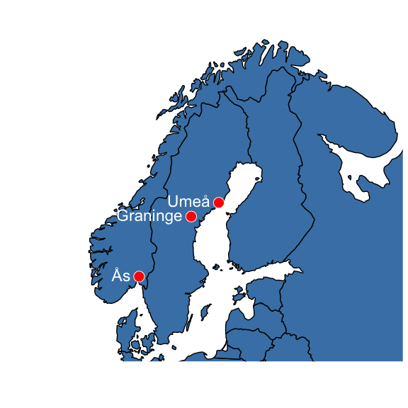

# What are we going to look at?

# Data!

- What is data?
- How can we format data?
- How to deal with big datasets?

# Source code!

```r
library(tidyverse)
library(maps)

nordic_map <- map_data("world",
                       region = c("sweden", "norway", "finland",
                                  "denmark", "germany", "poland",
                                  "estonia", "latvia", "lithuania",
                                  "russia", "belarus"))

locations <- tibble(
  name = c("Graninge", "Umeå", "Ås"),
  lat = c(63.07, 63.80, 59.67),
  long = c(16.94, 20.21, 10.77)
)

ggplot(nordic_map, aes(x = long, y = lat)) +
  geom_polygon(aes(group = group),
               fill = "steelblue",
               colour = "#CCCCCC") +
  geom_point(data = locations,
             fill = "red", colour = "white",
             size = 5, pch = 21) +
  geom_text(data = locations, aes(label = name),
            colour = "white",
            hjust = 1.3, vjust = 0.3,
            size = 12) +
  coord_map(xlim = c(0, 40), ylim = c(55, 71)) +
  labs(x = "Longitude", y = "Latitude") +
  theme_reveal_night()
```

# Figures!

- Best practices
- Accessibility

# Sharing stuff!

- How to share code
- How to ask for help
- Transparent research

# What do I expect you to know by the end of this course?

- Being able to use basic R commands to
  - parse data that you have generated
  - transform data to fit whatever downstream analysis you want to perform
  - perform various statistical test (this is not a statistics course though)
- Be able to describe what tidy data is and why this is something we would want to achieve
- Know what version control systems are used for and be able to describe pros and cons with using these

# Recommended literature

- R for Data Science  
  https://r4ds.had.co.nz/
- R graphics cookbook  
  https://r-graphics.org/
- Advanced R  
  https://adv-r.hadley.nz/
- ggplot2  
  https://ggplot2-book.org/

[figure not shown]

# A brief history of R

# Why R?

R and Rstudio is extremely versatile

All of the presentations that you will see during this course are made in Rstudio.